# FlowerPower

Sehaj Raina

March 7, 2019

1. Load packages

```r
suppressMessages(library(vegan))
suppressMessages(library(ape))
suppressMessages(library(ggplot2))
suppressMessages(library(ggtree))
```

2. Importing and data wrangling

```r
samples<-read.csv("flower.csv")

#change population from continuous to a categorical variable
str(samples$Population)
```

```
##  int [1:30] 7 7 7 7 7 7 3 3 3 3 ...
```

```r
samples$Population<-as.factor(samples$Population)

samples1<-read.csv("flower.csv", header=T, row.names="Quadrate")

table1<- samples1[, -c(1:5)] #do not need these columns for analysis

x<-rowSums(table1)
sum(x)
```

```
## [1] 3101
```

```r
Drop<-rowSums(table1) < 1
sum(Drop) #nothing to drop
```

```
## [1] 0
```

3. Visualization by Location - Binary Distance Matrix

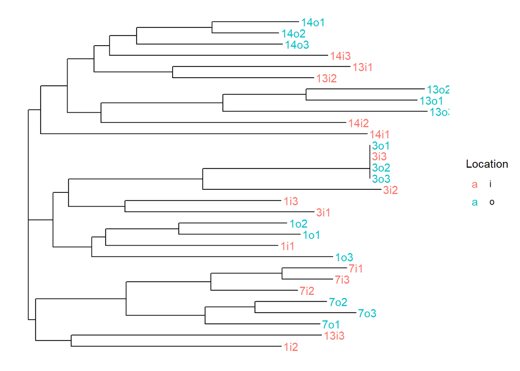

```r
table1_bin<-table1 #convert to binary
table1_bin[table1_bin>0]<-1

table1_bin_dist<-dist(table1_bin, method="binary")

table1_tree<-nj(table1_bin_dist)
ggtree(table1_tree, layout="rectangular") %<+% samples +
  geom_tiplab(aes(colour=Location)) +
  theme(legend.position="right")
```

### **Figure 1.** *Binary Distance Matrix Tree by Location*

4. Visualization by Location - Dissimilarity

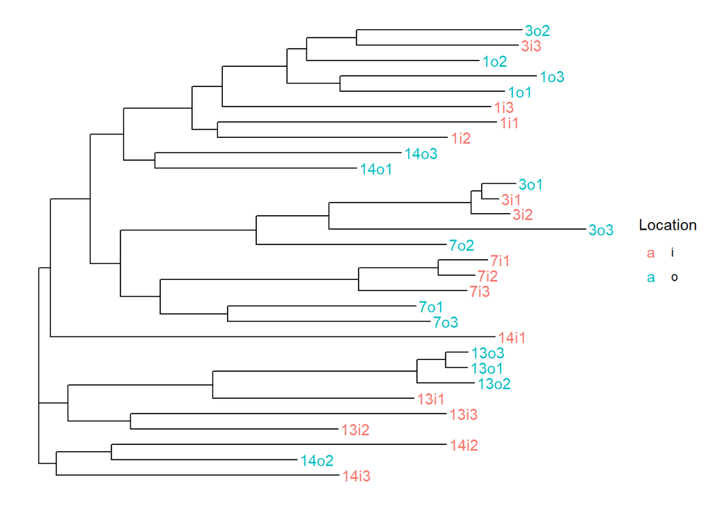

```r
table1_dist<- vegdist(table1) #use the data WE DIDNT transform to binary

table1_tree2<-nj(table1_dist)
ggtree(table1_tree2,layout="rectangular") %<+% samples +
  geom_tiplab(aes(color=Location)) +
  theme(legend.position="right")
```

### **Figure 2.** *Dissimilarity Tree by Location*

5. Visualization by Location - NMDS

```r
NMDSdat<-metaMDS(table1_dist, k=2)
```

```
## *** Solution reached
```

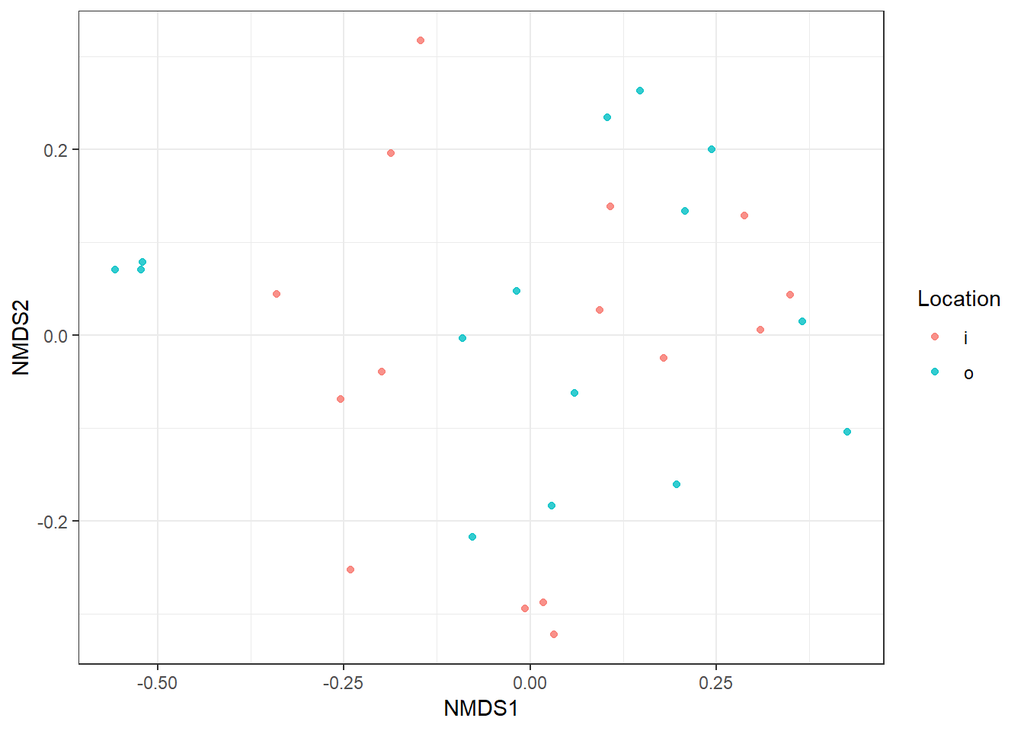

```r
PDat<-data.frame(NMDS1=NMDSdat$point[,1],
                 NMDS2=NMDSdat$point[,2],
                 Quadrate=row.names(table1))

PDat<-merge(PDat,samples,by="Quadrate",all.x=T,all.y=F) #join data sets

qplot(x=NMDS1,y=NMDS2,colour=Location,alpha=I(0.8),data=PDat)+theme_bw()
```

### **Figure 3.** *Non-Metric Multidimensional Scaling (NMDS) by Location*

6. Visualization by Population - Binary Distance Matrix

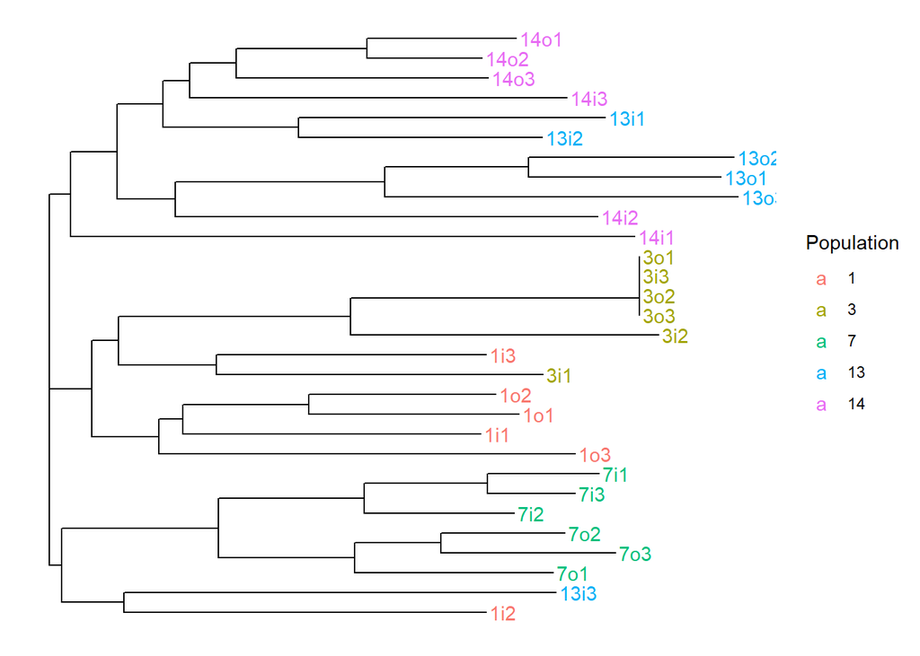

```r
table3_tree<-nj(table1_bin_dist)
ggtree(table3_tree, layout="rectangular") %<+% samples +
  geom_tiplab(aes(colour=Population)) +
  theme(legend.position="right")
```

### **Figure 4.** *Binary Distance Matrix Tree by Population*

7. Visualization by Population - Dissimilarity

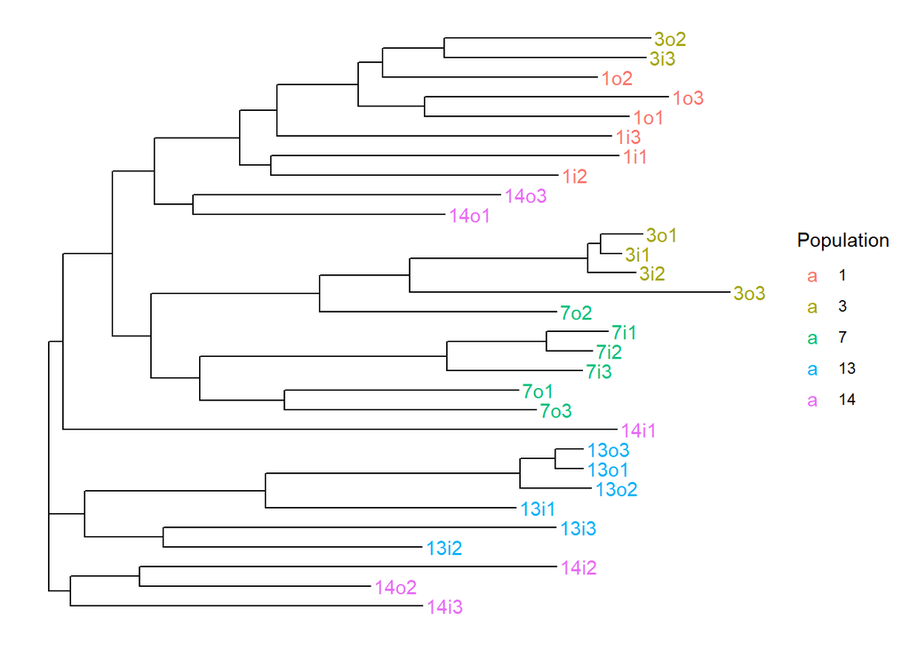

```r
table4_tree2<-nj(table1_dist)
ggtree(table1_tree2,layout="rectangular") %<+% samples +
  geom_tiplab(aes(color=Population)) +
  theme(legend.position="right")
```

### **Figure 5.** *Dissimilarity Tree by Population*

8. Visualization by Population - NMDS

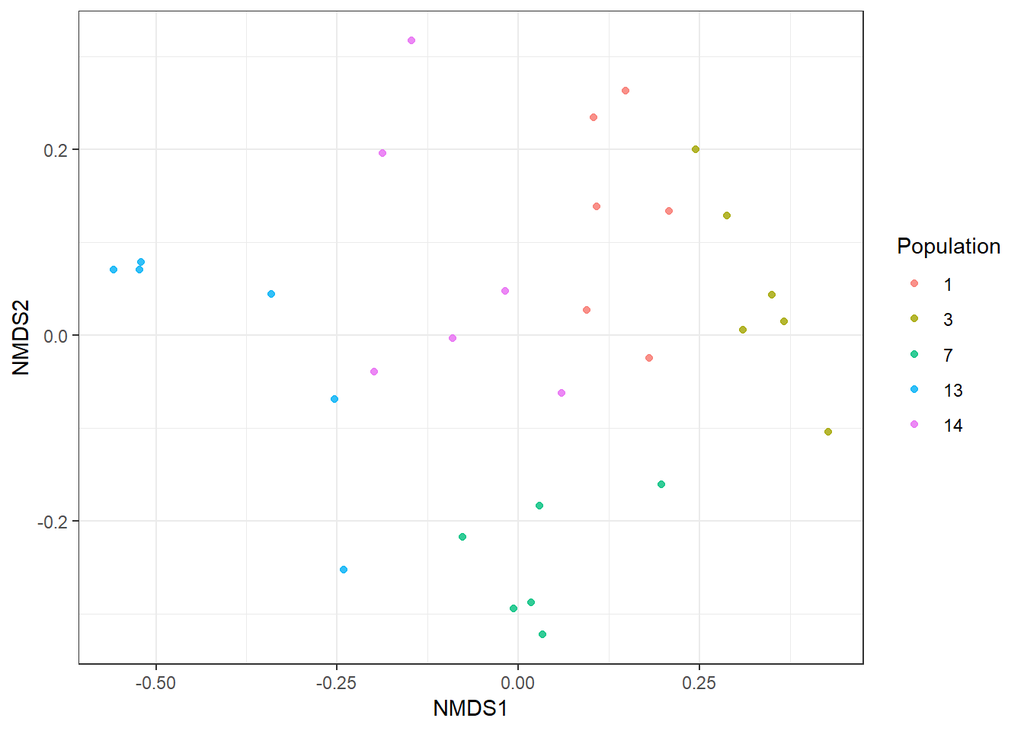

```r
qplot(x=NMDS1,y=NMDS2,colour=Population,alpha=I(0.8),data=PDat)+theme_bw()
```

### **Figure 6.** *Non-Metric Multidimensional Scaling (NMDS) by Population*

9. Visualization by Location and Population - NMDS

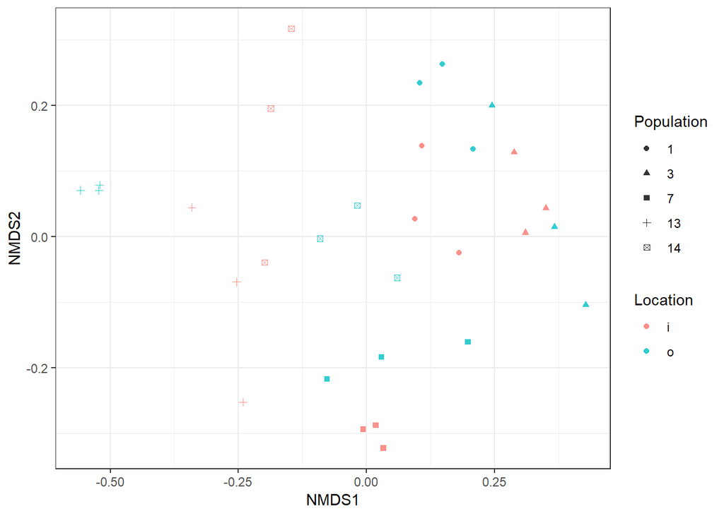

```r
qplot(x=NMDS1,y=NMDS2,shape=Population, colour=Location, alpha=I(0.8),data=PDat)+theme_bw()
```

### **Figure 7.** *Non-Metric Multidimensional Scaling (NMDS) by Location and Population*

##### When we look at Figures 4, 5 and 6, we can see that the sampling population also has a strong effect on plant communities because the clustering on similarity and dissimilarity trees in figures 4 and 5 show clearer distinctions amongst populations of plant communities. Furthermore, we see the same strong clustering pattern in Figure 6.

##### Figure 7 shows that when comparing the effects of location AND population on the distribution of plant communities, population seems to have a stronger effect than the absence/presence of garlic mustard, because the clusters based on sampling populations is tighter and much less uniformly distributed.